# Practice Assignment 1.4

```python
import numpy as np
import pandas as pd
```

```python
data_dir = "https://dlsun.github.io/pods/data/"
df_titanic = pd.read_csv(data_dir + "titanic.csv")
```

```python
total_vals=pd.crosstab(df_titanic["class"], df_titanic["embarked"], normalize=True)
total_vals
```

| embarked class | B | C | Q | S |
| --- | --- | --- | --- | --- |
| 1st | 0.001359 | 0.064794 | 0.001359 | 0.079293 |
| 2nd | 0.002719 | 0.011781 | 0.003172 | 0.111010 |
| 3rd | 0.000000 | 0.046217 | 0.051201 | 0.223833 |
| deck crew | 0.010421 | 0.000000 | 0.000000 | 0.019483 |
| engineering crew | 0.019483 | 0.000000 | 0.000000 | 0.127322 |
| restaurant staff | 0.000000 | 0.000000 | 0.000000 | 0.031264 |
| victualling crew | 0.055279 | 0.000000 | 0.000000 | 0.140009 |

## 2. Using the joint distribution that calculated above, calculate the following:

- the conditional distribution of their class given where they embarked
- the conditional distribution of where they embarked given their class

Conditional distribution of class given where they embarked:

```python
df_titanic_B = df_titanic[df_titanic["embarked"]=="B"]
df_titanic_C = df_titanic[df_titanic["embarked"]=="C"]
df_titanic_Q = df_titanic[df_titanic["embarked"]=="Q"]
df_titanic_S = df_titanic[df_titanic["embarked"]=="S"]
```

```python
B_cond=df_titanic_B["class"].value_counts(normalize=True)
C_cond=df_titanic_C["class"].value_counts(normalize=True)
Q_cond=df_titanic_Q["class"].value_counts(normalize=True)
S_cond=df_titanic_S["class"].value_counts(normalize=True)
```

```python
B_cond
```

```
class
victualling crew    0.619289
engineering crew    0.218274
deck crew           0.116751
2nd                 0.030457
1st                 0.015228
Name: proportion, dtype: float64
```

Conditional distribution of embark location given class:

```python
df_titanic_1=df_titanic[df_titanic["class"]=="1st"]
df_titanic_2=df_titanic[df_titanic["class"]=="2nd"]
df_titanic_3=df_titanic[df_titanic["class"]=="3rd"]
df_titanic_victualling=df_titanic[df_titanic["class"]=="victualling crew"]
df_titanic_engineering=df_titanic[df_titanic["class"]=="engineering crew"]
df_titanic_deck=df_titanic[df_titanic["class"]=="deck crew"]
df_titanic_rest=df_titanic[df_titanic["class"]=="restaurant staff"]
```

```python
first=df_titanic_1["embarked"].value_counts(normalize=True)
second=df_titanic_2["embarked"].value_counts(normalize=True)
third=df_titanic_3["embarked"].value_counts(normalize=True)
victualling=df_titanic_victualling["embarked"].value_counts(normalize=True)
engineer=df_titanic_engineering["embarked"].value_counts(normalize=True)
deck=df_titanic_deck["embarked"].value_counts(normalize=True)
restaurant=df_titanic_rest["embarked"].value_counts(normalize=True)
```

```python
first
```

```
embarked
S    0.540123
C    0.441358
B    0.009259
Q    0.009259
Name: proportion, dtype: float64
```

Use the conditional distributions that you calculate to answer the following quesitons:

- What proportion of 3rd class passengers embarked at Southampton?

```python
third["S"]
```

```
np.float64(0.6967559943582511)
```

69.68% of 3rd class passengers embared at Southhampton.

- What proportion of Southampton passengers were in 3rd class?

```python
S_cond["3rd"]
```

```
np.float64(0.3056930693069307)
```

30.57% of Southhampton passengers were in 3rd class.

## 3. Make a visualization showing the distribution of a passenger’s class, given where they embarked.

```python
import plotnine as p9
```

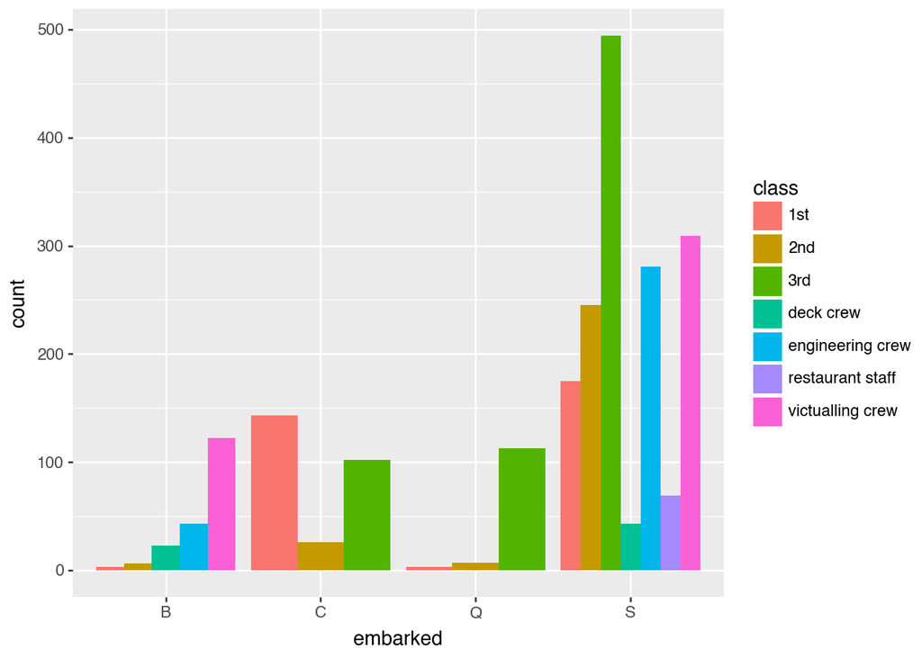

```python
(p9.ggplot(df_titanic,
p9.aes(
  x = "embarked",
  fill = "class"
))
+ p9.geom_bar(position = "dodge")
)
```

The full visualization gives a good broader picture of how the embarking locations compare to each other in terms of passengers boarded, where in the conditional probability tables it is hard to get this bigger picture. However, the tables are preffered to the visualization in terms of being able to get specific/exact proportions easily.